# 통계분석 기법을 이용한 가설 검정

WONSIK JEONG

2017 11 7

# 데이터 분석에 필요한 가장 간단한 통계지식

#### 왜 통계를 알아야 하는가?

- **간단한 오류의 사례**

[figure not shown]

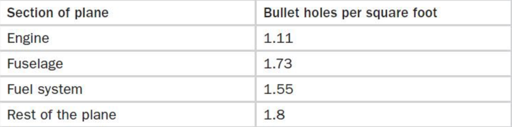

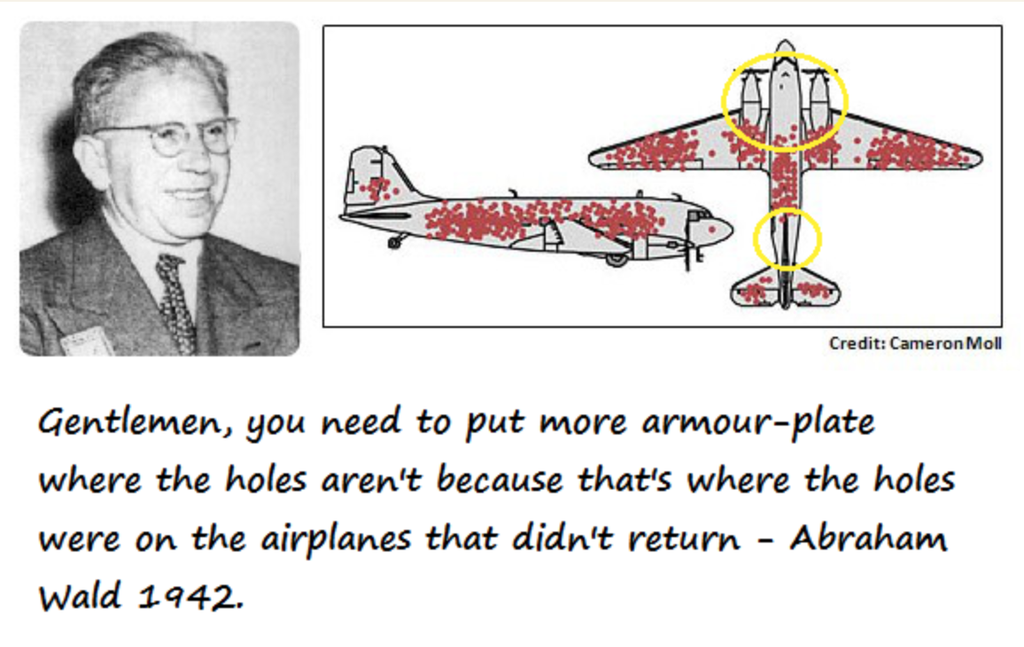

```
+ 생존편향 : 왜곡된 표본에서 살아남은 것만 고려하고 실패한 것은 고려하지 않는 오류
+ ex) 왠지 나는 당첨될 것 같은 로또, 연예인과 창업가들의 성공예시에만 주목 등
```

## 13-1. 통계적 가설 검정이란?

#### 기술 통계와 추론 통계

- **기술 통계(Descriptive statistics)**
  - 데이터를 요약해 설명하는 통계 기법
  - ex) 사람들이 받는 월급을 집계해 전체 월급 평균 구하기
- **추론 통계(Inferential statistics)**
  - 단순히 숫자를 요약하는 것을 넘어 어떤 값이 발생할 확률을 계산하는 통계 기법
  - ex) 수집된 데이터에서 성별에 따라 월급에 차이가 있는 것으로 나타났을 때, 이런 차이가 우연히 발생할 확률을 계산
- **추론 통계(Inferential statistics)**
  - 이런 차이가 우연히 나타날 확률이 작다
    - -> 성별에 따른 월급 차이가 통계적으로 유의하다(statistically significant)고 결론
  - 이런 차이가 우연히 나타날 확률이 크다
    - -> 성별에 따른 월급 차이가 통계적으로 유의하지 않다(not statistically significant)고 결론
  - 기술 통계 분석에서 집단 간 차이가 있는 것으로 나타났더라도 이는 우연에 의한 차이일 수 있음
    - 데이터를 이용해 신뢰할 수 있는 결론을 내리려면 유의확률을 계산하는 통계적 가설 검정 절차를 거쳐야 함

#### 통계적 가설 검정

- **통계적 가설 검정(Statistical hypothesis test)**
  - 유의확률을 이용해 가설을 검정하는 방법
- **유의확률(Significance probability, p-value)**
  - 실제로는 집단 간 차이가 없는데 우연히 차이가 있는 데이터가 추출될 확률
  - 분석 결과 유의확률이 크게 나타났다면
    - ’집단 간 차이가 통계적으로 유의하지 않다’고 해석
    - 실제로 차이가 없더라도 우연에 의해 이 정도의 차이가 관찰될 가능성이 크다는 의미
  - 분석 결과 유의확률이 작게 나타났다면
    - ’집단 간 차이가 통계적으로 유의하다’고 해석
    - 실제로 차이가 없는데 우연히 이 정도의 차이가 관찰될 가 능성이 작다, 우연이라고 보기 힘들다는 의미
- **추가 설명**
  - 귀무가설 : 직접 검증의 대상이 되는 가설로 연구자가 부정하고자 하는 가설
  - 대립가설 : 귀무가설에 반대되는 사실로 연구자가 주장하고자 하는 가설
  - 1종 오류 : 귀무가설이 참이지만 기각하는 경우 ( 내 의견이 틀렸는데 맞았다고 하는 것 )
  - 2종 오류 : 귀무가설이 거짓이지만 채택하는 경우 ( 내 의견이 맞았는데 틀렸다고 하는 것 )

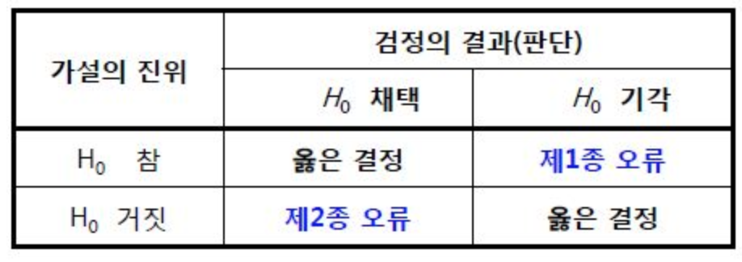

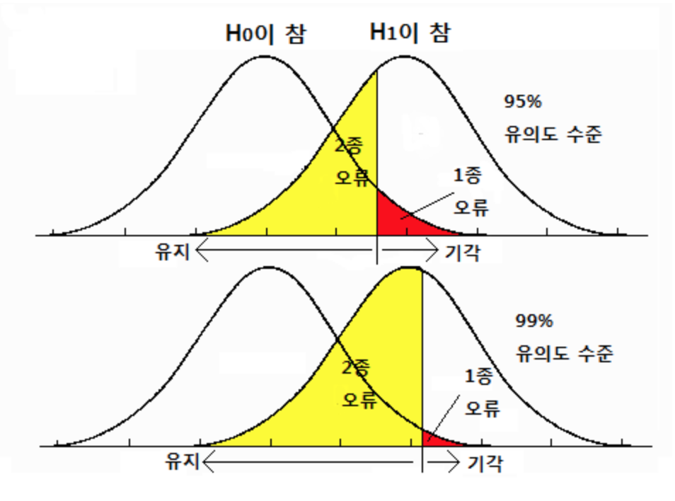

### 13-2. t 검정 - 두 집단의 평균 비교

#### t 검정(t-test)

- 두 집단의 평균에 통계적으로 유의한 차이가 있는지 알아볼 때 사용하는 통계 분석 기법

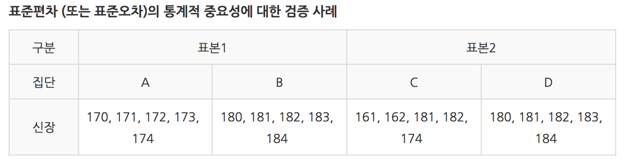

- **표본 1은 평균이 유의미한 차이를 지니지만, 표본 2는 평균이 유의미한 차이를 가지지 못한다**

### compact 자동차와 suv 자동차의 도시 연비 t 검정

#### 데이터 준비

```r
mpg <- as.data.frame(ggplot2::mpg)

library(dplyr)
mpg_diff <- mpg %>%
  select(class, cty) %>%
  filter(class %in% c("compact", "suv"))

head(mpg_diff)
```

```
##     class cty
## 1 compact  18
## 2 compact  21
## 3 compact  20
## 4 compact  21
## 5 compact  16
## 6 compact  18
```

```r
table(mpg_diff$class)
```

```
##
## compact     suv
##      47      62
```

#### t-test

```r
t.test(data = mpg_diff, cty ~ class, var.equal = T)
```

```
##
##  Two Sample t-test
##
## data:  cty by class
## t = 11.917, df = 107, p-value < 2.2e-16
## alternative hypothesis: true difference in means is not equal to 0
## 95 percent confidence interval:
##  5.525180 7.730139
## sample estimates:
## mean in group compact     mean in group suv
##              20.12766              13.50000
```

### 일반 휘발유와 고급 휘발유의 도시 연비 t 검정

#### 데이터 준비

```r
mpg_diff2 <- mpg %>%
  select(fl, cty) %>%
  filter(fl %in% c("r", "p"))  # r:regular, p:premium

table(mpg_diff2$fl)
```

```
##
##   p   r
##  52 168
```

#### t-test

```r
t.test(data = mpg_diff2, cty ~ fl, var.equal = T)
```

```
##
##  Two Sample t-test
##
## data:  cty by fl
## t = 1.0662, df = 218, p-value = 0.2875
## alternative hypothesis: true difference in means is not equal to 0
## 95 percent confidence interval:
##  -0.5322946  1.7868733
## sample estimates:
## mean in group p mean in group r
##        17.36538        16.73810
```

## 13-3. 상관분석 - 두 변수의 관계성 분석

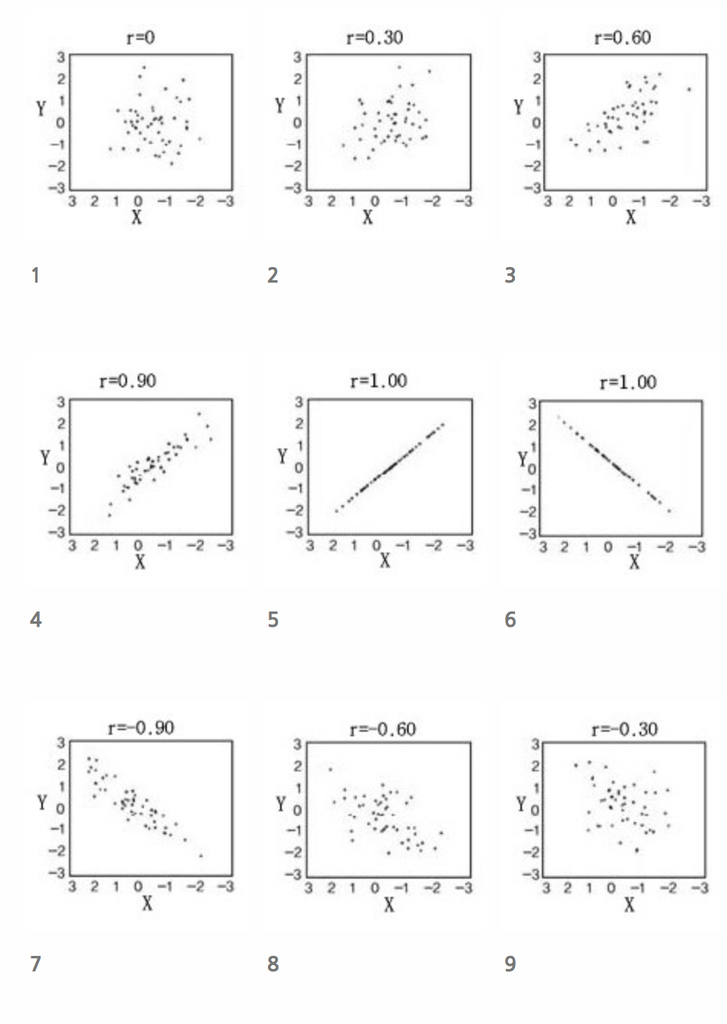

그림 1

### 실업자 수와 개인 소비 지출의 상관관계

#### 데이터 준비

```r
economics <- as.data.frame(ggplot2::economics)
```

### 상관분석

```r
cor.test(economics$unemploy, economics$pce)
```

```
##
##  Pearson's product-moment correlation
##
## data:  economics$unemploy and economics$pce
## t = 18.605, df = 572, p-value < 2.2e-16
## alternative hypothesis: true correlation is not equal to 0
## 95 percent confidence interval:
##  0.5603164 0.6625460
## sample estimates:
##       cor
## 0.6139997
```

### 상관행렬 히트맵 만들기

- 상관행렬(Correlation Matrix)
  - 여러 변수 간 상관계수를 행렬로 타나낸 표
  - 어떤 변수끼리 관련이 크고 적은지 파악할 수 있음

#### 데이터 준비

```r
head(mtcars)
```

```
##                    mpg cyl disp  hp drat    wt  qsec vs am gear carb
## Mazda RX4         21.0   6  160 110 3.90 2.620 16.46  0  1    4    4
## Mazda RX4 Wag     21.0   6  160 110 3.90 2.875 17.02  0  1    4    4
## Datsun 710        22.8   4  108  93 3.85 2.320 18.61  1  1    4    1
## Hornet 4 Drive    21.4   6  258 110 3.08 3.215 19.44  1  0    3    1
## Hornet Sportabout 18.7   8  360 175 3.15 3.440 17.02  0  0    3    2
## Valiant           18.1   6  225 105 2.76 3.460 20.22  1  0    3    1
```

#### 상관행렬 만들기

```r
car_cor <- cor(mtcars)  # 상관행렬 생성
round(car_cor, 2)       # 소수점 셋째 자리에서 반올림해서 출력
```

```
##        mpg   cyl  disp    hp  drat    wt  qsec    vs    am  gear  carb
## mpg   1.00 -0.85 -0.85 -0.78  0.68 -0.87  0.42  0.66  0.60  0.48 -0.55
## cyl  -0.85  1.00  0.90  0.83 -0.70  0.78 -0.59 -0.81 -0.52 -0.49  0.53
## disp -0.85  0.90  1.00  0.79 -0.71  0.89 -0.43 -0.71 -0.59 -0.56  0.39
## hp   -0.78  0.83  0.79  1.00 -0.45  0.66 -0.71 -0.72 -0.24 -0.13  0.75
## drat  0.68 -0.70 -0.71 -0.45  1.00 -0.71  0.09  0.44  0.71  0.70 -0.09
## wt   -0.87  0.78  0.89  0.66 -0.71  1.00 -0.17 -0.55 -0.69 -0.58  0.43
## qsec  0.42 -0.59 -0.43 -0.71  0.09 -0.17  1.00  0.74 -0.23 -0.21 -0.66
## vs    0.66 -0.81 -0.71 -0.72  0.44 -0.55  0.74  1.00  0.17  0.21 -0.57
## am    0.60 -0.52 -0.59 -0.24  0.71 -0.69 -0.23  0.17  1.00  0.79  0.06
## gear  0.48 -0.49 -0.56 -0.13  0.70 -0.58 -0.21  0.21  0.79  1.00  0.27
## carb -0.55  0.53  0.39  0.75 -0.09  0.43 -0.66 -0.57  0.06  0.27  1.00
```

#### 상관행렬 히트맵 만들기

- 히트맵(heat map) : 값의 크기를 색깔로 표현한 그래프

```r
install.packages("corrplot")
library(corrplot)
```

```r
corrplot(car_cor)
```

[output not shown]

#### 원 대신 상관계수 표시

```r
corrplot(car_cor, method = "number")
```

[output not shown]

#### 다양한 파라미터 지정하기

```r
col <- colorRampPalette(c("#BB4444", "#EE9988", "#FFFFFF", "#77AADD", "#4477AA"))

corrplot(car_cor,
         method = "color",       # 색깔로 표현
         col = col(200),         # 색상 200개 선정
         type = "lower",         # 왼쪽 아래 행렬만 표시
         order = "hclust",       # 유사한 상관계수끼리 군집화
         addCoef.col = "black",  # 상관계수 색깔
         tl.col = "black",       # 변수명 색깔
         tl.srt = 45,            # 변수명 45도 기울임
         diag = F)               # 대각 행렬 제외
```

[output not shown]